# How LSU Events Affect Crime in Baton Rouge, LA

# Crime Rates by LSU Outcome

Considering the personal investment most people have with their sports team, it’s not too far off to say that some of their actions may be affected based on the outcome of a game. The chart below shows how crimes numbers and types of crimes are affect based on the outcome of LSU games. As you can see, crimes actually increase based on if LSU wins, more specificially in the other and Theft categories. This shows how LSU events can influence individuals to potentially act out of their normal attitudes.

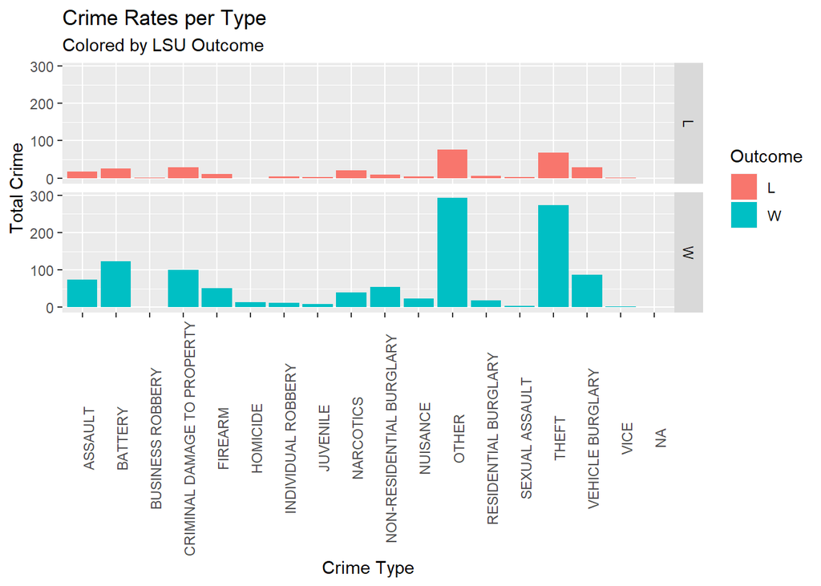

# Opponent’s Effect on Crime Rates

As detailed in the graph below we see the count of crimes committed by the opponent LSU was facing at the time, as well as the outcome of the game that day. What we can derive from this is opponents have little effect on the amount of crimes committed in a given day, with the exception of the peak crime date for the Louisiana Tech game, I guess that’s what you get when you put Louisiana up against Louisiana.

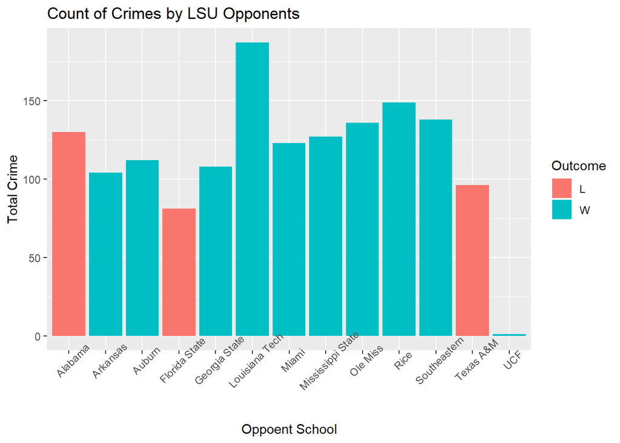